# ST558_Project1

Qiaozhi Bao 9/18/2020

- Packages Used for Reading JSON Data
  - httr
  - jsonlite
  - dplyr
  - knitr
  - ggplot2
  - tidyverse
  - devtools
- Accessing NHL Data
  - Creating a Function for Accessing Franchise-team-total Data
  - Creating a Function for Accessing Franchise-records Data
  - Creating a Function for Accessing stats Data
  - One-Stop-Shop function
- Exploratory Data Analysis
  - With active franchises are more likely to win or lose?
  - Data Cleaning
  - The difference that game type and active status generate in wins and looses,homewins and roadwins,homelosses and roadlosses.

# Packages Used for Reading JSON Data

## httr

## jsonlite

## dplyr

## knitr

## ggplot2

## tidyverse

## devtools

Library list:Below are the libraries we may use

```r
library(httr)
library(jsonlite)
library(dplyr)
```

```r
library(knitr)
library(ggplot2)
library(tidyverse)
library(devtools)
```

# Accessing NHL Data

```r
# The get_franchise will access and get the parses data from /franchise endpoint.
base_url1 <-  "https://records.nhl.com/site/api/franchise"
get_franchise <- function(ID=NULL){
  json1<- GET(base_url1) %>% content("text") %>% fromJSON(flatten = TRUE) %>% as.data.frame() %>% tbl_df()
if(is.null(ID)==FALSE){json<-filter(json1,data.id==ID)}
return(json1)
}
# Test if the function works
get_franchise() # It works well.
```

```
## No encoding supplied: defaulting to UTF-8.

## Warning: `tbl_df()` is deprecated as of dplyr 1.0.0.
## Please use `tibble::as_tibble()` instead.
```

## Creating a Function for Accessing Franchise-team-total Data

```r
#  a function here to get the franchise-team-totals data sets by specifying any id number
base_url_total<- "https://records.nhl.com/site/api/franchise-team-totals"
get_data_totals <- function(ID=NULL){
json<- GET(base_url_total) %>% content("text") %>% fromJSON(flatten = TRUE) %>% as.data.frame()
if(is.null(ID)==FALSE){json<-filter(json,data.franchiseId==ID)}
return(tbl_df(json))
}
# Test if the function works
get_data_totals()# It works well.
```

```
## No encoding supplied: defaulting to UTF-8.
```

## Creating a Function for Accessing Franchise-records Data

For this function you have the option to input franchiseName or franchiseId,both them can get the data you want.You only need to know one of them, and this function can convert franchiseName to franchiseId.

```r
base_url2 <-"https://records.nhl.com/site/api/franchise-"
get_records <- function(modifier,ID){
if(is.numeric(ID)){
full_url2 <- paste0(base_url2,modifier,'=',ID)
son2 <- GET(full_url2) %>% content("text") %>% fromJSON(flatten = TRUE)
json2
  }
   else{
     full_url2 <- paste0(base_url2,modifier)
     json2 <- GET(full_url2) %>% content("text") %>% fromJSON(flatten = TRUE)
     json2 <- filter(json2[[1]],franchiseName==ID)
     json2
   }
}
# Test if the function works
get_records('season-records?cayenneExp=franchiseId','Toronto Maple Leafs')
```

```
## No encoding supplied: defaulting to UTF-8.
```

```r
#It works well.
```

## Creating a Function for Accessing stats Data

```r
stats<-function(ID=NULL, modifier=NULL){
   if (is.null(ID)){url<-"https://statsapi.web.nhl.com/api/v1/teams"}
     else {url<-paste0("https://statsapi.web.nhl.com/api/v1/teams/",ID)}
   json_stats<-if(is.null(modifier)){url}
         else {paste0(url,modifier)}
   json_stats <- GET(json_stats) %>% content("text") %>% fromJSON(flatten = TRUE)%>%as.data.frame()
  return(tbl_df(json_stats))
}
# test if the function works
stats(ID=NULL,'?expand=team.roster')# It works well.
```

## One-Stop-Shop function

```r
# one stop shop function
one_stop_shop <- function(endpoint,ID=NULL,modifier=NULL){
   if(is.null(endpoint)){stop("Wrong endpoint")}
  else if(endpoint=='franchise'){get_franchise(ID)}
  else if(endpoint=='franchise-team-totals'){get_data_totals(ID)}
  else if(endpoint=='franchise-'){get_records(modifier,ID)}
  else if(endpoint=='teams' ){stats(ID,modifier)}
  else if(endpoint=='teams/'){stats(ID,modifier)}
}
# checking if one-stop-shop function works.
test_stats<-one_stop_shop('teams')
tese_franchise_totals<-one_stop_shop("franchise-team-totals")
```

```
## No encoding supplied: defaulting to UTF-8.
```

# Exploratory Data Analysis

## With active franchises are more likely to win or lose?

We want to see if active status and a game type will affect the game results.Using `mutate` function to create some new variables,and using `full_join` to join some data sets we are interested with different endpoints by `franchiseId`.After some data cleaning we make some plots,like boxplots,scaterplotts,barplots and etc to help us find some associations.Not too surprisingly,the variables `activefranchise` and `gametypeid` have some effects on the game results.

```r
# franchise data
franchise_data <- get_franchise()
```

```
## No encoding supplied: defaulting to UTF-8.
```

```r
franchise_data<- franchise_data %>% rename(data.franchiseId=data.id)
franchise_data
# franchise_total data
franchise_total <- get_data_totals()
```

```
## No encoding supplied: defaulting to UTF-8.
```

```r
franchise_total
# Group franchise_total data by franchiseId
franchise_total_1 <- group_by(franchise_total,data.franchiseId) %>%
  summarise(totalhomeLosses=sum(data.homeLosses),
            totalhomeWins=sum(data.homeWins),
            data.activeFranchise =data.activeFranchise,
            data.gameTypeId=data.gameTypeId,
             data.homeLosses=data.homeLosses,
            data.losses=data.losses,
            data.homeWins=data.homeWins,
            data.wins=data.wins,
             data.roadLosses=data.roadLosses,
            data.roadWins=data.roadWins,

          )
# use full_join() to combine the two data sets
# Create new variables
combined <- full_join(franchise_total_1,franchise_data)%>%
  mutate(HomeWinsPercent = data.homeWins/data.wins) %>%
  mutate( HomeLossesPercent = data.homeLosses/data.losses)%>%
  mutate(RoadWinsPercent = data.roadWins/data.wins) %>%
  mutate( RoadLossesPercent = data.roadLosses/data.losses)
```

## Data Cleaning

```r
# change some variables to factor and define their factor levels
combined$data.activeFranchise <- as.factor(combined$data.activeFranchise)
levels(combined$data.activeFranchise) <- list('Active'= 1, 'Non-Active'= 0)
combined$data.gameTypeId <- as.factor(combined$data.gameTypeId)
levels(combined$data.gameTypeId) <- list('Type 2' =2 ,'Type 3'=3)
# using filter() to select the rows with game Type 2 and game Type 3
id_2 <- combined %>% filter(data.gameTypeId =='Type 2')
id_3 <- combined %>% filter(data.gameTypeId =="Type 3")
kable(head(combined),caption = "preview of combined data")
```

| data.franchiseId | totalhomeLosses | totalhomeWins | data.activeFranchise | data.gameTypeId | data.homeLosses | data.losses | data.homeWins | data.wins | data.roadLosses | data.roadWins | data.firstSeasonId | data.lastSeasonId | data.mostRecentTeamId | data.teamCommonName | data.teamPlaceName | total | HomeWinsPercent | HomeLossesPercent | RoadWinsPercent | RoadLossesPercent |
| --- | --- | --- | --- | --- | --- | --- | --- | --- | --- | --- | --- | --- | --- | --- | --- | --- | --- | --- | --- | --- |
| 1 | 1001 | 2279 | Active | Type 3 | 131 | 317 | 254 | 434 | 186 | 180 | 19171918 | NA | 8 | Canadiens | Montréal | 38 | 0.5852535 | 0.4132492 | 0.4147465 | 0.5867508 |
| 1 | 1001 | 2279 | Active | Type 2 | 870 | 2281 | 2025 | 3449 | 1411 | 1424 | 19171918 | NA | 8 | Canadiens | Montréal | 38 | 0.5871267 | 0.3814117 | 0.4128733 | 0.6185883 |
| 2 | 2 | 1 | Non-Active | Type 2 | 2 | 5 | 1 | 1 | 3 | 0 | 19171918 | 19171918 | 41 | Wanderers | Montreal | 38 | 1.0000000 | 0.4000000 | 0.0000000 | 0.6000000 |
| 3 | 102 | 173 | Non-Active | Type 3 | 7 | 17 | 6 | 18 | 10 | 12 | 19171918 | 19341935 | 45 | Eagles | St. Louis | 38 | 0.3333333 | 0.4117647 | 0.6666667 | 0.5882353 |
| 3 | 102 | 173 | Non-Active | Type 2 | 81 | 221 | 160 | 258 | 140 | 98 | 19171918 | 19341935 | 45 | Eagles | St. Louis | 38 | 0.6201550 | 0.3665158 | 0.3798450 | 0.6334842 |
| 3 | 102 | 173 | Non-Active | Type 2 | 14 | 31 | 7 | 11 | 17 | 4 | 19171918 | 19341935 | 45 | Eagles | St. Louis | 38 | 0.6363636 | 0.4516129 | 0.3636364 | 0.5483871 |

preview of combined data

```r
kable(table(combined$data.activeFranchise,combined$data.gameTypeId))
```

|  | Type 2 | Type 3 |
| --- | --- | --- |
| Active | 44 | 43 |
| Non-Active | 13 | 5 |

## The difference that game type and active status generate in wins and looses,homewins and roadwins,homelosses and roadlosses.

We want to see how different game type affect homewins roadwins,homelosses and roadlosses.

```r
# Type 2  wins
# for active franchise
type2_wins <- id_2 %>% select(data.activeFranchise,data.wins, data.homeWins, data.roadWins)%>%
  filter(data.activeFranchise == 'Active') %>%
  summarise(wins=sum(data.wins),
            homewins=sum(data.homeWins),
            roadwins=sum(data.roadWins))
# for non-active franchise
type2_wins_non <- id_2 %>% select(data.activeFranchise,data.wins, data.homeWins, data.roadWins)%>%
  filter(data.activeFranchise == 'Non-Active') %>%
  summarise(wins=sum(data.wins),
            homewins=sum(data.homeWins),
            roadwins=sum(data.roadWins))
table_type2_wins <- data.frame(c('Active','Non-Active'),wins=c(50938,1147),homewins=c(29436,718),roadwins=c(21502,429))
table_type2_wins
```

[output not shown]

```r
# Type 2  losses
# for active franchise
type2_losses <- id_2 %>% select(data.activeFranchise,data.losses, data.homeLosses, data.roadLosses)%>%
  filter(data.activeFranchise == 'Active') %>%
  summarise(losses=sum(data.losses),
            homelosses=sum(data.homeLosses),
            roadlosses=sum(data.roadLosses))
# for non-active franchise
type2_losses_non <- id_2 %>% select(data.activeFranchise,data.losses, data.homeLosses, data.roadLosses)%>%
  filter(data.activeFranchise == 'Non-Active') %>%
   summarise(losses=sum(data.losses),
            homelosses=sum(data.homeLosses),
            roadlosses=sum(data.roadLosses))
table_type2_lossses <- data.frame(c('Active','Non-Active'),losses=c(45599,1663),homelosses=c(18925,660),roadlosses=c(21502,429))
table_type2_lossses
```

[output not shown]

```r
# Type 3 wins
# for active franchies
type3_wins <- id_3 %>% select(data.activeFranchise,data.wins, data.homeWins, data.roadWins)%>%
  filter(data.activeFranchise == 'Active') %>%
  summarise(wins=sum(data.wins),
            homewins=sum(data.homeWins),
            roadwins=sum(data.roadWins))
# for non-active franchies
type3_wins_non <- id_3 %>% select(data.activeFranchise,data.wins,data.homeWins, data.roadWins)%>%
  filter(data.activeFranchise == 'Non-Active') %>%
  summarise(wins=sum(data.wins),
            homewins=sum(data.homeWins),
            roadwins=sum(data.roadWins))
table_type3_wins <- data.frame(c('Active','Non-Active'),wins=c(4357,58),homewins=c(2505,21),roadwins=c(1870,29))
table_type3_wins
```

[output not shown]

```r
# Type 3  losses
# for active franchise
type3_losses <- id_3 %>% select(data.activeFranchise,data.losses, data.homeLosses, data.roadLosses)%>%
  filter(data.activeFranchise == 'Active') %>%
  summarise(losses=sum(data.losses),
            homelosses=sum(data.homeLosses),
            roadlosses=sum(data.roadLosses))
# for non-active franchise
type3_losses_non <- id_3 %>% select(data.activeFranchise,data.losses, data.homeLosses, data.roadLosses)%>%
  filter(data.activeFranchise == 'Non-Active') %>%
   summarise(losses=sum(data.losses),
            homelosses=sum(data.homeLosses),
            roadlosses=sum(data.roadLosses))
table_type3_losses<- data.frame(c('Active','Non-Active'),losses=c(4352,59),homelosses=c(1866,27),roadlosses=c(2486,32))
table_type3_losses
```

[output not shown]

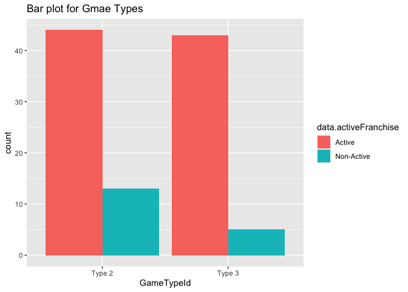

```r
#barplots
# The bar plot show us that active franchise are much more than Non-active franchise
ggplot(combined,aes(x=data.gameTypeId))+
  geom_bar(aes(fill= data.activeFranchise),position='dodge')+ xlab('GameTypeId')+
  ggtitle('Bar plot for Gmae Types')
```

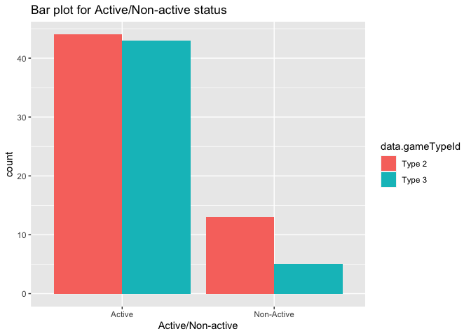

```r
ggplot(combined,aes(x=data.activeFranchise))+
  geom_bar(aes(fill= data.gameTypeId),position='dodge')+xlab('Active/Non-active')+
  ggtitle('Bar plot for Active/Non-active status')
```

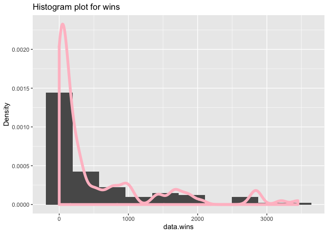

```r
par(mfrow=c(2,3))
g <- ggplot(combined,aes(x=data.wins,..density..))
g+geom_histogram(bins = 10) +ylab("Density") + geom_density(adjust=0.4,lwd=2,color='pink',outline.type = 'full')+
  ggtitle("Histogram plot for wins")
```

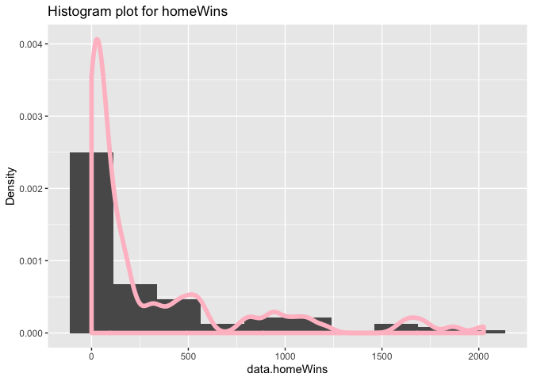

```r
g <- ggplot(combined,aes(x=data.homeWins,..density..))
g+geom_histogram(bins = 10) +ylab("Density") + geom_density(adjust=0.4,lwd=2,color='pink',outline.type = 'full')+
   ggtitle("Histogram plot for homeWins")
```

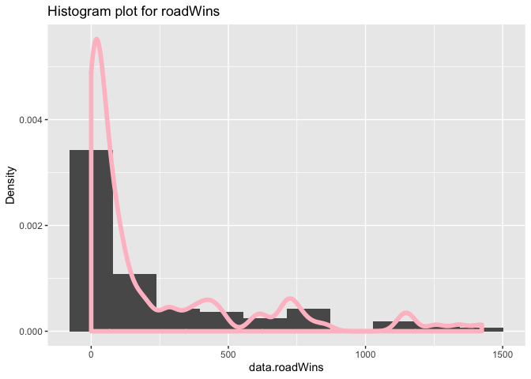

```r
g <- ggplot(combined,aes(x=data.roadWins,..density..))
g+geom_histogram(bins = 10) +ylab("Density") + geom_density(adjust=0.4,lwd=2,color='pink',outline.type = 'full')+
   ggtitle("Histogram plot for roadWins")
```

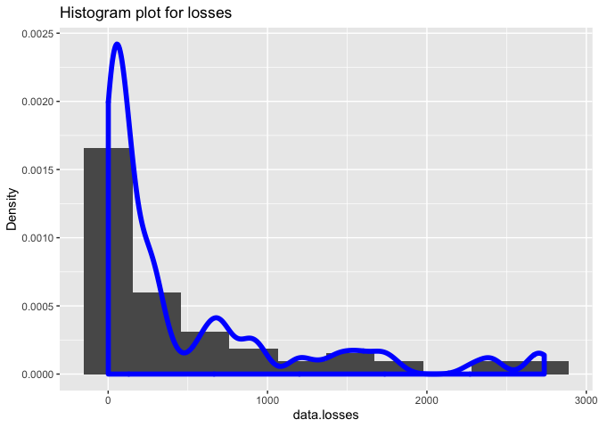

```r
g <- ggplot(combined,aes(x=data.losses,..density..))
g+geom_histogram(bins = 10) +ylab("Density") + geom_density(adjust=0.4,lwd=2,color='blue',outline.type = 'full')+
  ggtitle("Histogram plot for losses")
```

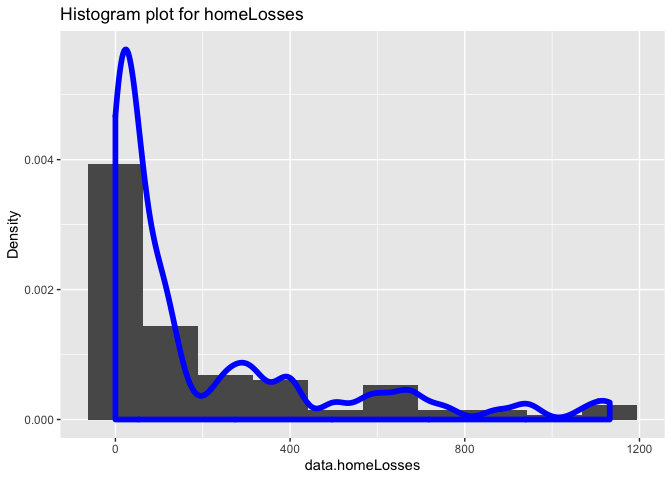

```r
g <- ggplot(combined,aes(x=data.homeLosses,..density..))
g+geom_histogram(bins = 10) +ylab("Density") + geom_density(adjust=0.4,lwd=2,color='blue',outline.type = 'full')+
   ggtitle("Histogram plot for homeLosses")
```

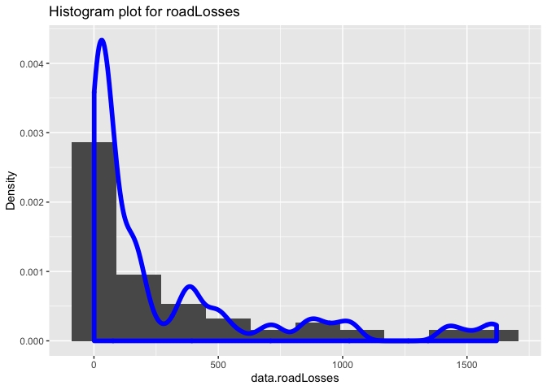

```r
g <- ggplot(combined,aes(x=data.roadLosses,..density..))
g+geom_histogram(bins = 10) +ylab("Density") + geom_density(adjust=0.4,lwd=2,color='blue',outline.type = 'full')+
   ggtitle("Histogram plot for roadLosses")
```

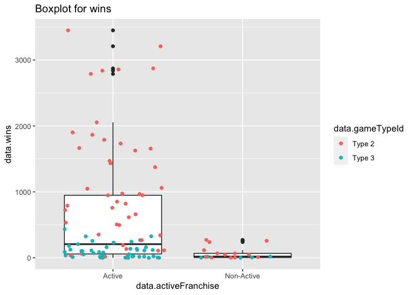

```r
# From the following boxplots we can see for active franchise with type 2 game are more likely to have high losses or wins;Active franchise with type 3 games are more likely to have low losses or wins
ggplot(combined,aes(x=data.activeFranchise,y=data.wins)) +
  geom_boxplot(fill='white')+
  geom_jitter(aes(color=data.gameTypeId))+
  ggtitle('Boxplot for wins')
```

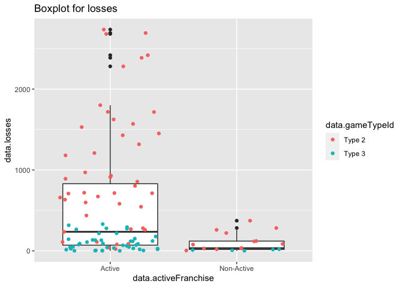

```r
ggplot(combined,aes(x=data.activeFranchise,y=data.losses)) +
  geom_boxplot(fill='white')+
  geom_jitter(aes(color=data.gameTypeId))+
  ggtitle('Boxplot for losses')
```

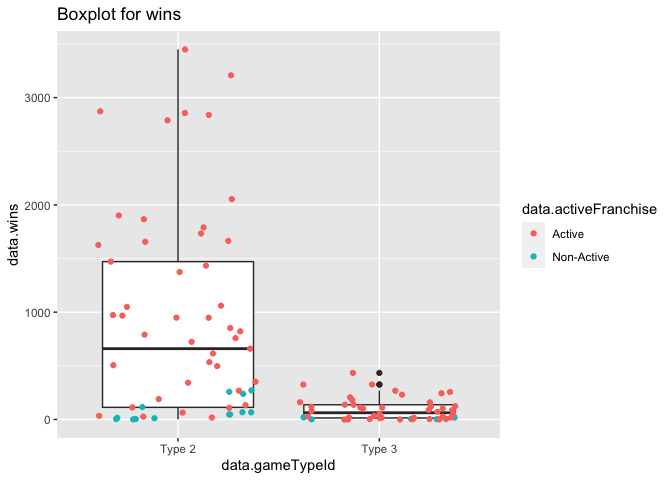

```r
ggplot(combined,aes(x=data.gameTypeId,y=data.wins)) +
  geom_boxplot(fill='white')+
  geom_jitter(aes(color=data.activeFranchise))+
  ggtitle('Boxplot for wins')
```

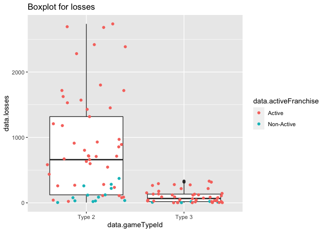

```r
ggplot(combined,aes(x=data.gameTypeId,y=data.losses)) +
  geom_boxplot(fill='white')+
  geom_jitter(aes(color=data.activeFranchise))+
  ggtitle('Boxplot for losses')
```

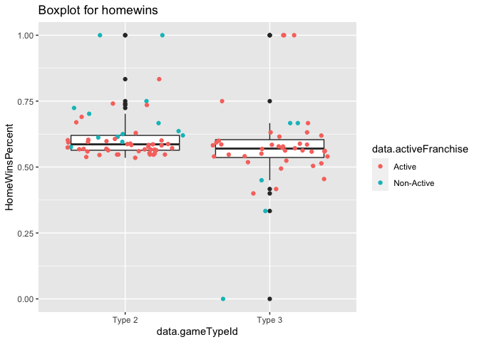

```r
ggplot(combined,aes(x=data.gameTypeId,y=HomeWinsPercent)) +
  geom_boxplot(fill='white')+
  geom_jitter(aes(color=data.activeFranchise))+
  ggtitle('Boxplot for homewins')
```

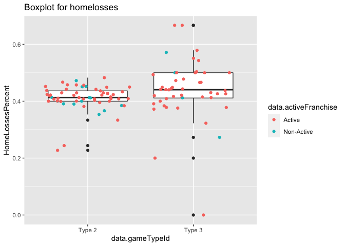

```r
ggplot(combined,aes(x=data.gameTypeId,y=HomeLossesPercent)) +
  geom_boxplot(fill='white')+
  geom_jitter(aes(color=data.activeFranchise))+
  ggtitle('Boxplot for homelosses')
```

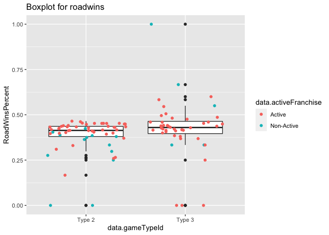

```r
ggplot(combined,aes(x=data.gameTypeId,y=RoadWinsPercent)) +
  geom_boxplot(fill='white')+
  geom_jitter(aes(color=data.activeFranchise))+
  ggtitle('Boxplot for roadwins')
```

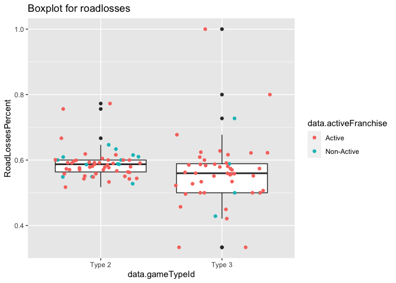

```r
ggplot(combined,aes(x=data.gameTypeId,y=RoadLossesPercent)) +
  geom_boxplot(fill='white')+
  geom_jitter(aes(color=data.activeFranchise))+
  ggtitle('Boxplot for roadlosses')
```

The four plots show that type 3 game accounts less roadlosses percentage and more homelosses percentage.

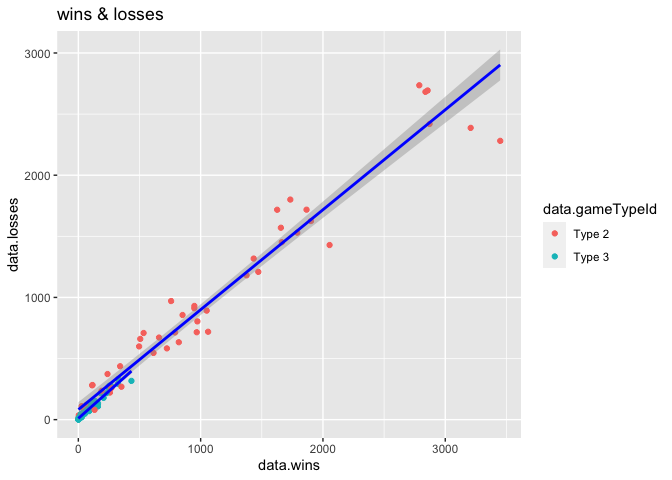

```r
# The two scatterplots show us usually high wins associated with high losses
# Active/Type 2 accounts more wins and losses
ggplot(combined,aes(x=data.wins,y=data.losses,group=data.gameTypeId)) +
  geom_jitter(aes(color=data.gameTypeId)) +
  geom_smooth(method='lm',col='blue')+
  ggtitle("wins & losses")
```

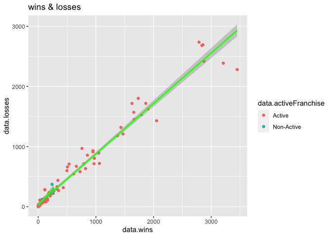

```r
ggplot(combined,aes(x=data.wins,y=data.losses,group=data.activeFranchise)) +
  geom_jitter(aes(color=data.activeFranchise)) +
  geom_smooth(method='lm',col='green')+
  ggtitle("wins & losses")
```

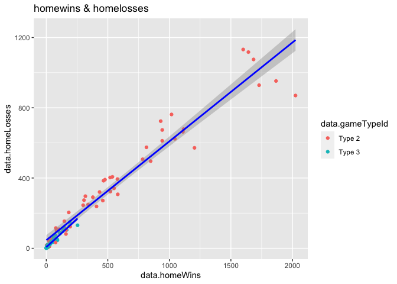

```r
ggplot(combined,aes(x=data.homeWins,y=data.homeLosses,group=data.gameTypeId)) +
  geom_jitter(aes(color=data.gameTypeId)) +
  geom_smooth(method='lm',col='blue')+
  ggtitle("homewins & homelosses")
```

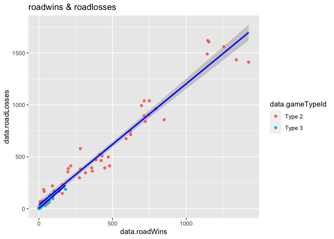

```r
ggplot(combined,aes(x=data.roadWins,y=data.roadLosses,group=data.gameTypeId)) +
  geom_jitter(aes(color=data.gameTypeId)) +
  geom_smooth(method='lm',col='blue')+
  ggtitle("roadwins & roadlosses")
```

We actually got the consistent conclusion from the above barplots,histogram plots,boxplots and scatterplots with before.Active franchise with game type 2 are more likely to have high wins or looses,usually high wins are associated with high losses,but the overall wins are a slightly more than overall losses.

From the four scatterplots,it looks like the activefranchise and gametypeid have consistent effect on `wins/losses`,`homeWins/roadWins`,`homeLooses/roadLooses`.